# Lab2

## Лабораторная работа № 2

### Андрюшина Мария, 932001

### Задание №1

### RNN

```python
import pandas as pd
import numpy as np
import matplotlib.pyplot as plt
from sklearn.preprocessing import MinMaxScaler
from sklearn.metrics import mean_squared_error,mean_absolute_error,r2_score
import tensorflow as tf
from tensorflow import keras
from tensorflow.keras.layers import Dense, Dropout, Activation, SimpleRNN, GRU
from tensorflow.keras import layers
from tensorflow.keras.models import Sequential
from tensorflow.keras.callbacks import ModelCheckpoint,EarlyStopping
```

### Работа с данными

```python
df = pd.read_csv('Yakutsk_weather_19102020_01102012.csv', sep=';', encoding='windows-1251')
df.head()
```

|  | LocalTime | T | P0 | P | U | DD |
| --- | --- | --- | --- | --- | --- | --- |
| 0 | 19.10.2020 17:00 | -7.0 | 745.9 | 758.2 | 68.0 | Ветер |
| 1 | 19.10.2020 16:30 | -6.0 | 746.0 | 758.2 | 63.0 | Ветер |
| 2 | 19.10.2020 16:00 | -5.0 | 746.0 | 758.2 | 58.0 | Ветер |
| 3 | 19.10.2020 15:30 | -4.0 | 746.1 | 758.2 | 59.0 | Ветер |
| 4 | 19.10.2020 15:00 | -4.0 | 746.1 | 758.2 | 54.0 | Ветер |

Данные идут в обратном порядке. Поставим их в правильный порядок:

```python
df = df.loc[::-1].set_index(df.index)
```

```python
df
```

|  | LocalTime | T | P0 | P | U | DD |
| --- | --- | --- | --- | --- | --- | --- |
| 0 | 01.10.2012 00:00 | 2.0 | 744.4 | 756.2 | 87.0 | Ветер |
| 1 | 01.10.2012 01:00 | 2.0 | 744.4 | 756.2 | 87.0 | Ветер |
| 2 | 01.10.2012 02:00 | 2.0 | 743.6 | 755.4 | 87.0 | Ветер |
| 3 | 01.10.2012 03:00 | 2.0 | 743.6 | 755.4 | 87.0 | Ветер |
| 4 | 01.10.2012 04:00 | 2.0 | 742.8 | 754.6 | 87.0 | Ветер |
| ... | ... | ... | ... | ... | ... | ... |
| 116046 | 19.10.2020 15:00 | -4.0 | 746.1 | 758.2 | 54.0 | Ветер |
| 116047 | 19.10.2020 15:30 | -4.0 | 746.1 | 758.2 | 59.0 | Ветер |
| 116048 | 19.10.2020 16:00 | -5.0 | 746.0 | 758.2 | 58.0 | Ветер |
| 116049 | 19.10.2020 16:30 | -6.0 | 746.0 | 758.2 | 63.0 | Ветер |
| 116050 | 19.10.2020 17:00 | -7.0 | 745.9 | 758.2 | 68.0 | Ветер |

116051 rows × 6 columns

```python
df.info()
```

```
<class 'pandas.core.frame.DataFrame'>
RangeIndex: 116051 entries, 0 to 116050
Data columns (total 6 columns):
 #   Column     Non-Null Count   Dtype
---  ------     --------------   -----
 0   LocalTime  116051 non-null  object
 1   T          116050 non-null  float64
 2   P0         116049 non-null  float64
 3   P          116049 non-null  float64
 4   U          116048 non-null  float64
 5   DD         116048 non-null  object
dtypes: float64(4), object(2)
memory usage: 5.3+ MB
```

```python
df.isnull().sum()/df.shape[0]
```

```
LocalTime    0.000000
T            0.000009
P0           0.000017
P            0.000017
U            0.000026
DD           0.000026
dtype: float64
```

Есть пропущенные значения. Удалим строки с ними:

```python
df = df.dropna()
```

```python
df.isnull().sum().sum()
```

```
0
```

```python
df['DD'].value_counts()
```

```
Ветер                     99657
Штиль                     16250
Переменное направление      137
Name: DD, dtype: int64
```

Обработаем данные в столбце DD:

```python
df = pd.get_dummies(df, columns=['DD'], dtype = int)
df.head()
```

|  | LocalTime | T | P0 | P | U | DD_Ветер | DD_Переменное направление | DD_Штиль |
| --- | --- | --- | --- | --- | --- | --- | --- | --- |
| 0 | 01.10.2012 00:00 | 2.0 | 744.4 | 756.2 | 87.0 | 1 | 0 | 0 |
| 1 | 01.10.2012 01:00 | 2.0 | 744.4 | 756.2 | 87.0 | 1 | 0 | 0 |
| 2 | 01.10.2012 02:00 | 2.0 | 743.6 | 755.4 | 87.0 | 1 | 0 | 0 |
| 3 | 01.10.2012 03:00 | 2.0 | 743.6 | 755.4 | 87.0 | 1 | 0 | 0 |
| 4 | 01.10.2012 04:00 | 2.0 | 742.8 | 754.6 | 87.0 | 1 | 0 | 0 |

```python
df.isnull().sum().sum()
```

```
0
```

```python
min_max_scaler = MinMaxScaler()

df_temp = df['T'].values
df_temp = min_max_scaler.fit_transform(df_temp.reshape(-1, 1))
```

```python
print(df_temp.shape)
df_temp = df_temp.flatten()
print(df_temp.shape)
```

```
(116044, 1)
(116044,)
```

Разделим данные на тренировочную, валидационную и тестовую выборку:

```python
window = 15

n_samples=df_temp.shape[0]-window
n_train_samples=round(0.7*n_samples)
n_val_samples=round(0.1*n_samples)
n_test_samples=n_samples-n_train_samples-n_val_samples
print('Train = ',n_train_samples,'Validation = ',n_val_samples,'Test = ',n_test_samples)
```

```
Train =  81220 Validation =  11603 Test =  23206
```

```python
X_train=np.zeros((n_train_samples,window))
y_train=np.zeros(n_train_samples)

X_val=np.zeros((n_val_samples,window))
y_val=np.zeros(n_val_samples)

X_test=np.zeros((n_test_samples,window))
y_test=np.zeros(n_test_samples)
```

```python
for i in range(n_train_samples):
  for j in range(window):
    X_train[i,j]=df_temp[i+j]
  y_train[i]=df_temp[i+window]

for i in range(n_val_samples):
  for j in range(window):
    X_val[i,j]=df_temp[n_train_samples+i+j]
  y_val[i]=df_temp[n_train_samples+i+window]

for i in range(n_test_samples):
  for j in range(window):
    X_test[i,j]=df_temp[n_train_samples+n_val_samples+i+j]
  y_test[i]=df_temp[n_train_samples+n_val_samples+i+window]
```

### Создание моделей

#### Base Model

Создадим базовую модель нейронной сети, состоящую из 2 слоёв:

1. Слой SimpleRNN, 10 нейронов, функция активации - ReLU
2. 1 нейрон, функция активации - Linear

```python
simple_rnn_model = Sequential(
    [
        layers.SimpleRNN(10,activation='relu',input_shape=(window,1)),
        layers.Dense(1, activation = 'linear')
    ]
)
simple_rnn_model.summary()
```

```
Model: "sequential_4"
_________________________________________________________________
 Layer (type)                Output Shape              Param #
=================================================================
 simple_rnn_3 (SimpleRNN)    (None, 10)                120

 dense_4 (Dense)             (None, 1)                 11

=================================================================
Total params: 131 (524.00 Byte)
Trainable params: 131 (524.00 Byte)
Non-trainable params: 0 (0.00 Byte)
_________________________________________________________________
```

```python
simple_rnn_model.compile(loss='mse',optimizer='adam',metrics='mae')
```

```python
early_stop = EarlyStopping(monitor='val_mae',patience=3,mode='min',verbose=1)
checkpoint = ModelCheckpoint('simple_rnn-temperature-{epoch:02d}-{val_mae:.3f}.hdf5',
                              monitor='val_mae',verbose=1,mode='min',
                              save_best_only=True)
callbacks_list=[early_stop,checkpoint]
```

Зададим количество объектов в одном батче, равное 30, и число эпох, равное 40:

```python
simple_rnn_model_history = simple_rnn_model.fit(X_train,y_train,batch_size=30,epochs=40,
                                callbacks=callbacks_list,
                                validation_data=(X_val,y_val))
```

```
Epoch 1: val_mae improved from inf to 0.00767, saving model to simple_rnn-temperature-01-0.008.hdf5
```

```
Epoch 2: val_mae improved from 0.00767 to 0.00649, saving model to simple_rnn-temperature-02-0.006.hdf5
Epoch 3: val_mae did not improve from 0.00649
Epoch 4: val_mae improved from 0.00649 to 0.00631, saving model to simple_rnn-temperature-04-0.006.hdf5
Epoch 5: val_mae did not improve from 0.00631
Epoch 6: val_mae improved from 0.00631 to 0.00625, saving model to simple_rnn-temperature-06-0.006.hdf5
Epoch 7: val_mae did not improve from 0.00625
Epoch 8: val_mae did not improve from 0.00625
Epoch 9: val_mae did not improve from 0.00625
Epoch 9: early stopping
```

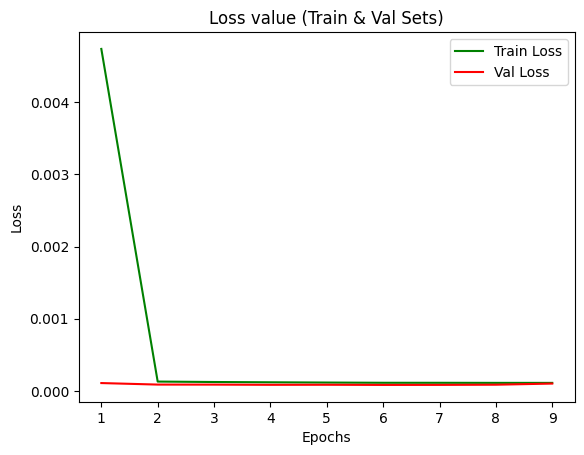

```python
loss_function = simple_rnn_model_history.history['loss']
val_loss_function = simple_rnn_model_history.history['val_loss']

epochs=range(1,len(loss_function)+1)

plt.title('Loss value (Train & Val Sets)')
plt.plot(epochs,loss_function,color='green',label='Train Loss')
plt.plot(epochs,val_loss_function,color='red',label='Val Loss')
plt.xlabel('Epochs')
plt.ylabel('Loss')
plt.legend()
plt.show()
```

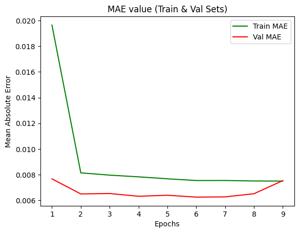

```python
mae_function = simple_rnn_model_history.history['mae']
val_mae_function = simple_rnn_model_history.history['val_mae']

epochs=range(1,len(loss_function)+1)

plt.title('MAE value (Train & Val Sets)')
plt.plot(epochs,mae_function,color='green',label='Train MAE')
plt.plot(epochs,val_mae_function,color='red',label='Val MAE')
plt.xlabel('Epochs')
plt.ylabel('Mean Absolute Error')
plt.legend()
plt.show()
```

```python
y_pred = simple_rnn_model.predict(X_test)
y_pred_inv = min_max_scaler.inverse_transform(y_pred)
y_test_inv = min_max_scaler.inverse_transform(y_test.reshape(-1,1))
print('MSE = ',round(mean_squared_error(y_true=y_test_inv,y_pred=y_pred_inv),3),' K degrees')
print('MAE = ',round(mean_absolute_error(y_true=y_test_inv,y_pred=y_pred_inv),3),' K degrees')
print('R2-score = ',round(r2_score(y_test_inv,y_pred_inv),3))
```

```
MSE =  0.0  K degrees
MAE =  0.008  K degrees
R2-score =  0.998
```

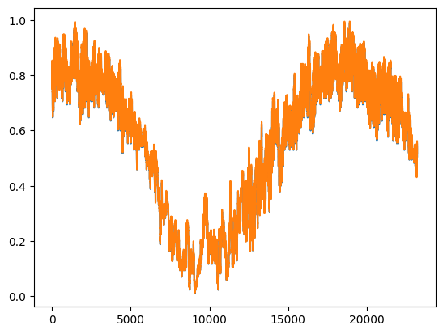

```python
plt.plot(range(1,len(y_test_inv)+1),y_test_inv)
plt.plot(range(1,len(y_pred_inv)+1),y_pred_inv)
```

Добавим остальные данные для обучения модели:

```python
df_all = df.drop('LocalTime', axis=1)
df_all = min_max_scaler.fit_transform(df_all)
```

```python
print(df_all.shape)
df_all = df_all.flatten()
print(df_all.shape)
```

```
(116044, 7)
(812308,)
```

```python
window_all = 20

n_samples_all=df_all.shape[0]-window_all
n_train_samples_all=round(0.7*n_samples_all)
n_val_samples_all=round(0.1*n_samples_all)
n_test_samples_all=n_samples_all-n_train_samples_all-n_val_samples_all
print('Train = ',n_train_samples_all,'Validation = ',n_val_samples_all,'Test = ',n_test_samples_all)
```

```
Train =  568602 Validation =  81229 Test =  162457
```

```python
X_train_all=np.zeros((n_train_samples_all,window_all,7))
y_train_all=np.zeros(n_train_samples_all)

X_val_all=np.zeros((n_val_samples_all,window_all,7))
y_val_all=np.zeros(n_val_samples_all)

X_test_all=np.zeros((n_test_samples_all,window_all,7))
y_test_all=np.zeros(n_test_samples_all)
```

```python
for i in range(n_train_samples_all):
  for j in range(window_all):
    X_train_all[i,j]=df_all[i+j]
  y_train_all[i]=df_all[i+window_all]

for i in range(n_val_samples_all):
  for j in range(window_all):
    X_val_all[i,j]=df_all[n_train_samples_all+i+j]
  y_val_all[i]=df_all[n_train_samples_all+i+window_all]

for i in range(n_test_samples_all):
  for j in range(window_all):
    X_test_all[i,j]=df_all[n_train_samples_all+n_val_samples_all+i+j]
  y_test_all[i]=df_all[n_train_samples_all+n_val_samples_all+i+window_all]
```

#### Second Model

Создадим вторую модель нейронной сети, состоящую из 2 слоёв:

1. Слой SimpleRNN, 20 нейронов, функция активации - ReLU
2. 1 нейрон, функция активации - Linear

```python
simple_rnn_all_model = Sequential(
    [
        layers.SimpleRNN(20,activation='relu',input_shape=(window_all,7)),
        layers.Dense(1, activation = 'linear')
    ]
)
simple_rnn_all_model.summary()
```

```
Model: "sequential_1"
_________________________________________________________________
 Layer (type)                Output Shape              Param #
=================================================================
 simple_rnn_1 (SimpleRNN)    (None, 20)                560

 dense_1 (Dense)             (None, 1)                 21

=================================================================
Total params: 581 (2.27 KB)
Trainable params: 581 (2.27 KB)
Non-trainable params: 0 (0.00 Byte)
_________________________________________________________________
```

```python
simple_rnn_all_model.compile(loss='mse',optimizer='adam',metrics='mae')
```

```python
early_stop = EarlyStopping(monitor='val_mae',patience=3,mode='min',verbose=1)
checkpoint = ModelCheckpoint('simple_rnn-temperature-{epoch:02d}-{val_mae:.3f}.hdf5',
                              monitor='val_mae',verbose=1,mode='min',
                              save_best_only=True)
callbacks_list=[early_stop,checkpoint]
```

Увеличим количество объектов в одном батче в 10 раз:

```python
simple_rnn_all_model_history = simple_rnn_all_model.fit(X_train_all,y_train_all,batch_size=300,epochs=40,
                                callbacks=callbacks_list,
                                validation_data=(X_val_all,y_val_all))
```

```
Epoch 1: val_mae improved from inf to 0.04675, saving model to simple_rnn-temperature-01-0.047.hdf5
```

```
Epoch 2: val_mae did not improve from 0.04675
Epoch 3: val_mae improved from 0.04675 to 0.04485, saving model to simple_rnn-temperature-03-0.045.hdf5
Epoch 4: val_mae improved from 0.04485 to 0.04241, saving model to simple_rnn-temperature-04-0.042.hdf5
Epoch 5: val_mae did not improve from 0.04241
Epoch 6: val_mae improved from 0.04241 to 0.03953, saving model to simple_rnn-temperature-06-0.040.hdf5
Epoch 7: val_mae did not improve from 0.03953
Epoch 8: val_mae did not improve from 0.03953
Epoch 9: val_mae did not improve from 0.03953
Epoch 9: early stopping
```

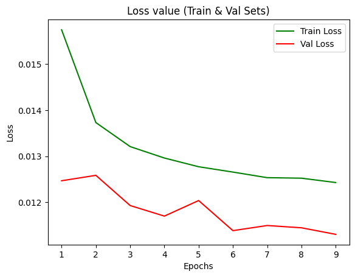

```python
loss_function = simple_rnn_all_model_history.history['loss']
val_loss_function = simple_rnn_all_model_history.history['val_loss']

epochs=range(1,len(loss_function)+1)

plt.title('Loss value (Train & Val Sets)')
plt.plot(epochs,loss_function,color='green',label='Train Loss')
plt.plot(epochs,val_loss_function,color='red',label='Val Loss')
plt.xlabel('Epochs')
plt.ylabel('Loss')
plt.legend()
plt.show()
```

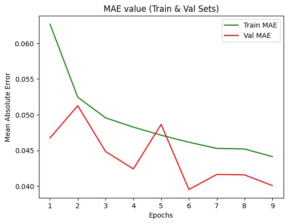

```python
mae_function = simple_rnn_all_model_history.history['mae']
val_mae_function = simple_rnn_all_model_history.history['val_mae']

epochs=range(1,len(loss_function)+1)

plt.title('MAE value (Train & Val Sets)')
plt.plot(epochs,mae_function,color='green',label='Train MAE')
plt.plot(epochs,val_mae_function,color='red',label='Val MAE')
plt.xlabel('Epochs')
plt.ylabel('Mean Absolute Error')
plt.legend()
plt.show()
```

```python
min_max_scaler.fit(y_train_all.reshape(-1, 1))
y_pred = simple_rnn_all_model.predict(X_test_all)
y_pred_inv = min_max_scaler.inverse_transform(y_pred)
y_test_inv = min_max_scaler.inverse_transform(y_test_all.reshape(-1,1))
print('MSE = ',round(mean_squared_error(y_true=y_test_inv,y_pred=y_pred_inv),3),' K degrees')
print('MAE = ',round(mean_absolute_error(y_true=y_test_inv,y_pred=y_pred_inv),3),' K degrees')
print('R2-score = ',round(r2_score(y_test_inv,y_pred_inv),3))
```

```
MSE =  0.006  K degrees
MAE =  0.031  K degrees
R2-score =  0.951
```

```python
x = X_test_all[2]
x = x.reshape((1,) + x.shape)
y_pred = simple_rnn_all_model.predict(x)
y_pred_inv = min_max_scaler.inverse_transform(y_pred)
truth = y_test_all[2]
truth_inv = min_max_scaler.inverse_transform(truth.reshape(-1, 1))
print('Предсказанная температура:', y_pred_inv[0, 0])
print('Реальная температура:', truth_inv[0, 0])
```

```
Предсказанная температура: 0.31073916
Реальная температура: 0.32188841201716656
```

### Задание №2

### Создание моделей

#### Base Model

Создадим базовую модель нейронной сети, состоящую из 2 слоёв:

1. Слой GRU, 10 нейронов
2. 1 нейрон, функция активации - Linear

```python
gru_model = Sequential(
    [
        layers.GRU(10,input_shape=(window,1)),
        layers.Dense(1, activation = 'linear')
    ]
)
gru_model.summary()
```

```
Model: "sequential_2"
_________________________________________________________________
 Layer (type)                Output Shape              Param #
=================================================================
 gru (GRU)                   (None, 10)                390

 dense_2 (Dense)             (None, 1)                 11

=================================================================
Total params: 401 (1.57 KB)
Trainable params: 401 (1.57 KB)
Non-trainable params: 0 (0.00 Byte)
_________________________________________________________________
```

```python
gru_model.compile(optimizer='adam',loss='mse',metrics='mae')
```

```python
early_stop = EarlyStopping(monitor='val_mae',patience=3,mode='min',verbose=1)
checkpoint = ModelCheckpoint('gru-temperature-{epoch:02d}-{val_mae:.3f}.hdf5',
                              monitor='val_mae',verbose=1,mode='min',
                              save_best_only=True)
callbacks_list=[early_stop,checkpoint]
```

Зададим количество объектов в одном батче, равное 30, и число эпох, равное 40:

```python
gru_model_history = gru_model.fit(X_train,y_train,batch_size=30,epochs=40,
                                callbacks=callbacks_list,
                                validation_data=(X_val,y_val))
```

```
Epoch 1: val_mae improved from inf to 0.00760, saving model to gru-temperature-01-0.008.hdf5
```

```
Epoch 2: val_mae improved from 0.00760 to 0.00632, saving model to gru-temperature-02-0.006.hdf5
Epoch 3: val_mae improved from 0.00632 to 0.00616, saving model to gru-temperature-03-0.006.hdf5
Epoch 4: val_mae did not improve from 0.00616
Epoch 5: val_mae did not improve from 0.00616
Epoch 6: val_mae did not improve from 0.00616
Epoch 6: early stopping
```

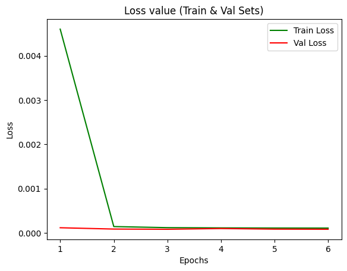

```python
loss_function = gru_model_history.history['loss']
val_loss_function = gru_model_history.history['val_loss']

epochs=range(1,len(loss_function)+1)

plt.title('Loss value (Train & Val Sets)')
plt.plot(epochs,loss_function,color='green',label='Train Loss')
plt.plot(epochs,val_loss_function,color='red',label='Val Loss')
plt.xlabel('Epochs')
plt.ylabel('Loss')
plt.legend()
plt.show()
```

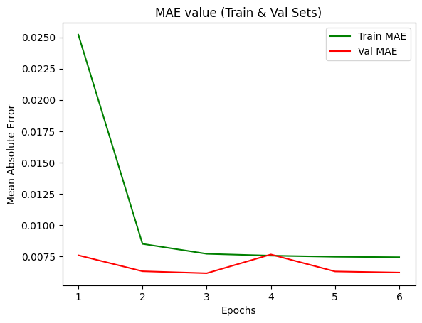

```python
mae_function = gru_model_history.history['mae']
val_mae_function = gru_model_history.history['val_mae']

epochs=range(1,len(loss_function)+1)

plt.title('MAE value (Train & Val Sets)')
plt.plot(epochs,mae_function,color='green',label='Train MAE')
plt.plot(epochs,val_mae_function,color='red',label='Val MAE')
plt.xlabel('Epochs')
plt.ylabel('Mean Absolute Error')
plt.legend()
plt.show()
```

```python
y_pred = gru_model.predict(X_test)
y_pred_inv = min_max_scaler.inverse_transform(y_pred)
y_test_inv = min_max_scaler.inverse_transform(y_test.reshape(-1,1))
print('MSE = ',round(mean_squared_error(y_true=y_test_inv,y_pred=y_pred_inv),3),' K degrees')
print('MAE = ',round(mean_absolute_error(y_true=y_test_inv,y_pred=y_pred_inv),3),' K degrees')
print('R2-score = ',round(r2_score(y_test_inv,y_pred_inv),3))
```

```
MSE =  0.0  K degrees
MAE =  0.007  K degrees
R2-score =  0.999
```

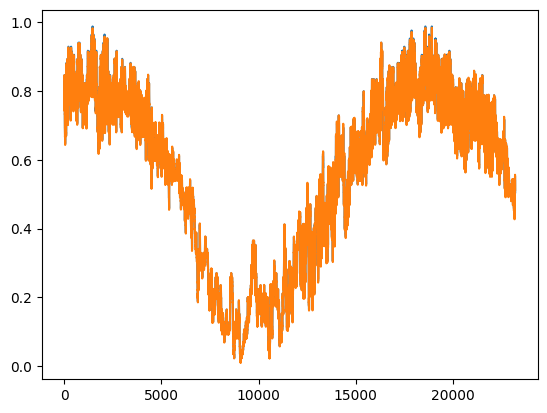

```python
plt.plot(range(1,len(y_test_inv)+1),y_test_inv)
plt.plot(range(1,len(y_pred_inv)+1),y_pred_inv)
```

#### Second Model

Создадим вторую модель нейронной сети, состоящую из 2 слоёв:

1. Слой GRU, 50 нейронов
2. 1 нейрон, функция активации - Linear

```python
gru_all_model = Sequential(
    [
        layers.GRU(50,input_shape=(window_all,7)),
        layers.Dense(1, activation = 'linear')
    ]
)
gru_all_model.summary()
```

```
Model: "sequential_8"
_________________________________________________________________
 Layer (type)                Output Shape              Param #
=================================================================
 gru_4 (GRU)                 (None, 50)                8850

 dense_8 (Dense)             (None, 1)                 51

=================================================================
Total params: 8901 (34.77 KB)
Trainable params: 8901 (34.77 KB)
Non-trainable params: 0 (0.00 Byte)
_________________________________________________________________
```

Изменим процедуру оптимизации на SGD:

```python
gru_all_model.compile(loss='mse',optimizer='SGD',metrics='mae')
```

```python
early_stop = EarlyStopping(monitor='val_mae',patience=3,mode='min',verbose=1)
checkpoint = ModelCheckpoint('gru-temperature-{epoch:02d}-{val_mae:.3f}.hdf5',
                              monitor='val_mae',verbose=1,mode='min',
                              save_best_only=True)
callbacks_list=[early_stop,checkpoint]
```

Увеличим количество объектов в одном батче в 5 раз:

```python
gru_all_model_history = gru_all_model.fit(X_train_all,y_train_all,batch_size=150,epochs=40,
                                callbacks=callbacks_list,
                                validation_data=(X_val_all,y_val_all))
```

```
Epoch 1: val_mae improved from inf to 0.23557, saving model to gru-temperature-01-0.236.hdf5
Epoch 2: val_mae improved from 0.23557 to 0.22266, saving model to gru-temperature-02-0.223.hdf5
Epoch 3: val_mae improved from 0.22266 to 0.22149, saving model to gru-temperature-03-0.221.hdf5
Epoch 4: val_mae improved from 0.22149 to 0.21956, saving model to gru-temperature-04-0.220.hdf5
Epoch 5: val_mae improved from 0.21956 to 0.21827, saving model to gru-temperature-05-0.218.hdf5
Epoch 6: val_mae improved from 0.21827 to 0.20561, saving model to gru-temperature-06-0.206.hdf5
Epoch 7: val_mae improved from 0.20561 to 0.16686, saving model to gru-temperature-07-0.167.hdf5
Epoch 8: val_mae improved from 0.16686 to 0.11918, saving model to gru-temperature-08-0.119.hdf5
Epoch 9: val_mae improved from 0.11918 to 0.10986, saving model to gru-temperature-09-0.110.hdf5
Epoch 10: val_mae improved from 0.10986 to 0.10548, saving model to gru-temperature-10-0.105.hdf5
Epoch 11: val_mae improved from 0.10548 to 0.10234, saving model to gru-temperature-11-0.102.hdf5
Epoch 12: val_mae improved from 0.10234 to 0.10218, saving model to gru-temperature-12-0.102.hdf5
Epoch 13: val_mae improved from 0.10218 to 0.09931, saving model to gru-temperature-13-0.099.hdf5
Epoch 14: val_mae did not improve from 0.09931
Epoch 15: val_mae did not improve from 0.09931
Epoch 16: val_mae improved from 0.09931 to 0.09424, saving model to gru-temperature-16-0.094.hdf5
Epoch 17: val_mae did not improve from 0.09424
Epoch 18: val_mae improved from 0.09424 to 0.09328, saving model to gru-temperature-18-0.093.hdf5
Epoch 19: val_mae did not improve from 0.09328
Epoch 20: val_mae improved from 0.09328 to 0.08874, saving model to gru-temperature-20-0.089.hdf5
Epoch 21: val_mae improved from 0.08874 to 0.08767, saving model to gru-temperature-21-0.088.hdf5
Epoch 22: val_mae did not improve from 0.08767
Epoch 23: val_mae did not improve from 0.08767
Epoch 24: val_mae did not improve from 0.08767
Epoch 24: early stopping
```

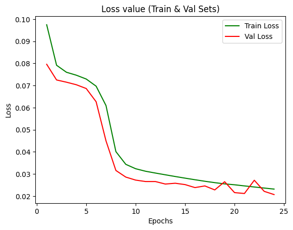

```python
loss_function = gru_all_model_history.history['loss']
val_loss_function = gru_all_model_history.history['val_loss']

epochs=range(1,len(loss_function)+1)

plt.title('Loss value (Train & Val Sets)')
plt.plot(epochs,loss_function,color='green',label='Train Loss')
plt.plot(epochs,val_loss_function,color='red',label='Val Loss')
plt.xlabel('Epochs')
plt.ylabel('Loss')
plt.legend()
plt.show()
```

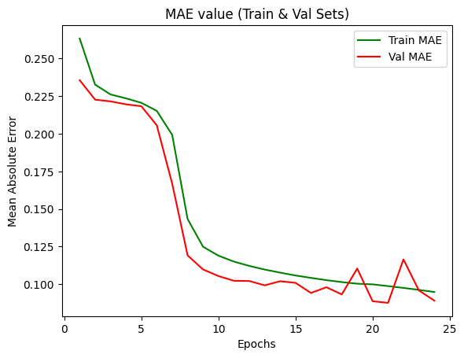

```python
mae_function = gru_all_model_history.history['mae']
val_mae_function = gru_all_model_history.history['val_mae']

epochs=range(1,len(loss_function)+1)

plt.title('MAE value (Train & Val Sets)')
plt.plot(epochs,mae_function,color='green',label='Train MAE')
plt.plot(epochs,val_mae_function,color='red',label='Val MAE')
plt.xlabel('Epochs')
plt.ylabel('Mean Absolute Error')
plt.legend()
plt.show()
```

```python
min_max_scaler.fit(y_train_all.reshape(-1, 1))
y_pred = gru_all_model.predict(X_test_all)
y_pred_inv = min_max_scaler.inverse_transform(y_pred)
y_test_inv = min_max_scaler.inverse_transform(y_test_all.reshape(-1,1))
print('MSE = ',round(mean_squared_error(y_true=y_test_inv,y_pred=y_pred_inv),3),' K degrees')
print('MAE = ',round(mean_absolute_error(y_true=y_test_inv,y_pred=y_pred_inv),3),' K degrees')
print('R2-score = ',round(r2_score(y_test_inv,y_pred_inv),3))
```

```
MSE =  0.014  K degrees
MAE =  0.078  K degrees
R2-score =  0.887
```

```python
x = X_test_all[2]
x = x.reshape((1,) + x.shape)
y_pred = gru_all_model.predict(x)
y_pred_inv = min_max_scaler.inverse_transform(y_pred)
truth = y_test_all[2]
truth_inv = min_max_scaler.inverse_transform(truth.reshape(-1, 1))
print('Предсказанная температура:', y_pred_inv[0, 0])
print('Реальная температура:', truth_inv[0, 0])
```

```
Предсказанная температура: 0.35199025
Реальная температура: 0.32188841201716656
```

### Задание №3

### Стек двух слоёв с GRU

### Создание моделей

#### Base Model

Создадим базовую модель нейронной сети, состоящую из 3 слоёв:

1. Слой GRU, 10 нейронов, функция активации - Relu
2. Слой GRU, 10 нейронов, функция активации - Relu
3. 1 нейрон, функция активации - Linear

```python
grugru_model = Sequential(
    [
        layers.GRU(10, activation='relu', input_shape=(window,1), return_sequences=True),
        layers.GRU(10, activation='relu'),
        layers.Dense(1, activation = 'linear')
    ]
)
grugru_model.summary()
```

```
Model: "sequential_9"
_________________________________________________________________
 Layer (type)                Output Shape              Param #
=================================================================
 gru_5 (GRU)                 (None, 15, 10)            390

 gru_6 (GRU)                 (None, 10)                660

 dense_9 (Dense)             (None, 1)                 11

=================================================================
Total params: 1061 (4.14 KB)
Trainable params: 1061 (4.14 KB)
Non-trainable params: 0 (0.00 Byte)
_________________________________________________________________
```

```python
grugru_model.compile(optimizer='adam',loss='mse',metrics='mae')
```

```python
early_stop = EarlyStopping(monitor='val_mae',patience=3,mode='min',verbose=1)
checkpoint = ModelCheckpoint('grugru-temperature-{epoch:02d}-{val_mae:.3f}.hdf5',
                              monitor='val_mae',verbose=1,mode='min',
                              save_best_only=True)
callbacks_list=[early_stop,checkpoint]
```

Зададим количество объектов в одном батче, равное 30, и число эпох, равное 40:

```python
grugru_model_history = grugru_model.fit(X_train,y_train,batch_size=30,epochs=40,
                                callbacks=callbacks_list,
                                validation_data=(X_val,y_val))
```

```
Epoch 1: val_mae improved from inf to 0.00671, saving model to grugru-temperature-01-0.007.hdf5
```

```
Epoch 2: val_mae improved from 0.00671 to 0.00635, saving model to grugru-temperature-02-0.006.hdf5
Epoch 3: val_mae did not improve from 0.00635
Epoch 4: val_mae improved from 0.00635 to 0.00617, saving model to grugru-temperature-04-0.006.hdf5
Epoch 5: val_mae did not improve from 0.00617
Epoch 6: val_mae did not improve from 0.00617
Epoch 7: val_mae did not improve from 0.00617
Epoch 7: early stopping
```

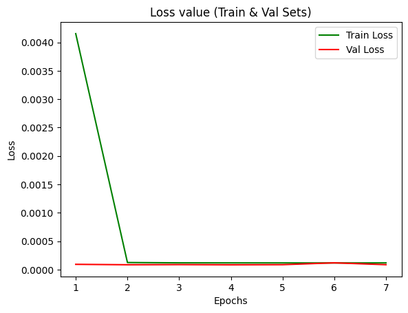

```python
loss_function = grugru_model_history.history['loss']
val_loss_function = grugru_model_history.history['val_loss']

epochs=range(1,len(loss_function)+1)

plt.title('Loss value (Train & Val Sets)')
plt.plot(epochs,loss_function,color='green',label='Train Loss')
plt.plot(epochs,val_loss_function,color='red',label='Val Loss')
plt.xlabel('Epochs')
plt.ylabel('Loss')
plt.legend()
plt.show()
```

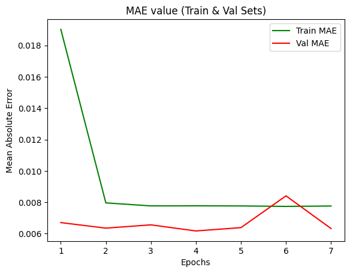

```python
mae_function = grugru_model_history.history['mae']
val_mae_function = grugru_model_history.history['val_mae']

epochs=range(1,len(loss_function)+1)

plt.title('MAE value (Train & Val Sets)')
plt.plot(epochs,mae_function,color='green',label='Train MAE')
plt.plot(epochs,val_mae_function,color='red',label='Val MAE')
plt.xlabel('Epochs')
plt.ylabel('Mean Absolute Error')
plt.legend()
plt.show()
```

```python
y_pred = grugru_model.predict(X_test)
y_pred_inv = min_max_scaler.inverse_transform(y_pred)
y_test_inv = min_max_scaler.inverse_transform(y_test.reshape(-1,1))
print('MSE = ',round(mean_squared_error(y_true=y_test_inv,y_pred=y_pred_inv),3),' K degrees')
print('MAE = ',round(mean_absolute_error(y_true=y_test_inv,y_pred=y_pred_inv),3),' K degrees')
print('R2-score = ',round(r2_score(y_test_inv,y_pred_inv),3))
```

```
MSE =  0.0  K degrees
MAE =  0.007  K degrees
R2-score =  0.999
```

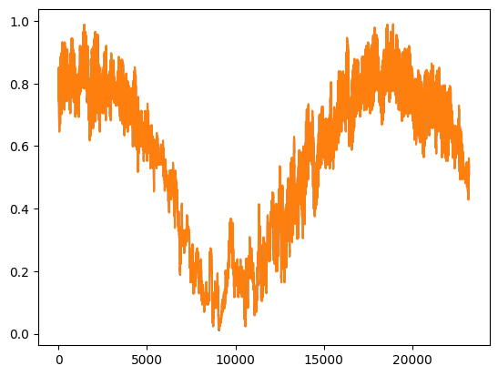

```python
plt.plot(range(1,len(y_test_inv)+1),y_test_inv)
plt.plot(range(1,len(y_pred_inv)+1),y_pred_inv)
```

#### Second Model

1. Слой GRU, 30 нейронов, функция активации - Relu
2. Dropout(0.1)
3. Слой GRU, 20 нейронов, функция активации - Relu
4. 1 нейрон, функция активации - Linear

```python
grugru_all_model = Sequential(
    [
        layers.GRU(30, activation='relu', input_shape=(window_all,7), return_sequences=True),
        layers.Dropout(0.1),
        layers.GRU(20, activation='relu'),
        layers.Dense(1, activation = 'linear')
    ]
)
grugru_all_model.summary()
```

```
Model: "sequential_12"
_________________________________________________________________
 Layer (type)                Output Shape              Param #
=================================================================
 gru_11 (GRU)                (None, 20, 30)            3510

 dropout_2 (Dropout)         (None, 20, 30)            0

 gru_12 (GRU)                (None, 20)                3120

 dense_12 (Dense)            (None, 1)                 21

=================================================================
Total params: 6651 (25.98 KB)
Trainable params: 6651 (25.98 KB)
Non-trainable params: 0 (0.00 Byte)
_________________________________________________________________
```

Изменим процедуру оптимизации на SGD:

```python
grugru_all_model.compile(loss='mse',optimizer='SGD',metrics='mae')
```

```python
early_stop = EarlyStopping(monitor='val_mae',patience=3,mode='min',verbose=1)
checkpoint = ModelCheckpoint('gru-temperature-{epoch:02d}-{val_mae:.3f}.hdf5',
                              monitor='val_mae',verbose=1,mode='min',
                              save_best_only=True)
callbacks_list=[early_stop,checkpoint]
```

Увеличим количество объектов в одном батче до 400:

```python
grugru_all_model_history = grugru_all_model.fit(X_train_all,y_train_all,batch_size=400,epochs=40,
                                callbacks=callbacks_list,
                                validation_data=(X_val_all,y_val_all))
```

```
Epoch 1: val_mae improved from inf to 0.26106, saving model to gru-temperature-01-0.261.hdf5
Epoch 2: val_mae improved from 0.26106 to 0.24470, saving model to gru-temperature-02-0.245.hdf5
Epoch 3: val_mae improved from 0.24470 to 0.23537, saving model to gru-temperature-03-0.235.hdf5
Epoch 4: val_mae improved from 0.23537 to 0.22201, saving model to gru-temperature-04-0.222.hdf5
Epoch 5: val_mae improved from 0.22201 to 0.21576, saving model to gru-temperature-05-0.216.hdf5
Epoch 6: val_mae improved from 0.21576 to 0.20646, saving model to gru-temperature-06-0.206.hdf5
Epoch 7: val_mae did not improve from 0.20646
Epoch 8: val_mae improved from 0.20646 to 0.19885, saving model to gru-temperature-08-0.199.hdf5
Epoch 9: val_mae improved from 0.19885 to 0.19175, saving model to gru-temperature-09-0.192.hdf5
Epoch 10: val_mae improved from 0.19175 to 0.18365, saving model to gru-temperature-10-0.184.hdf5
Epoch 11: val_mae improved from 0.18365 to 0.17633, saving model to gru-temperature-11-0.176.hdf5
Epoch 12: val_mae did not improve from 0.17633
Epoch 13: val_mae improved from 0.17633 to 0.17539, saving model to gru-temperature-13-0.175.hdf5
Epoch 14: val_mae improved from 0.17539 to 0.16783, saving model to gru-temperature-14-0.168.hdf5
Epoch 15: val_mae improved from 0.16783 to 0.16588, saving model to gru-temperature-15-0.166.hdf5
Epoch 16: val_mae improved from 0.16588 to 0.16204, saving model to gru-temperature-16-0.162.hdf5
Epoch 17: val_mae improved from 0.16204 to 0.15772, saving model to gru-temperature-17-0.158.hdf5
Epoch 18: val_mae improved from 0.15772 to 0.15237, saving model to gru-temperature-18-0.152.hdf5
Epoch 19: val_mae did not improve from 0.15237
Epoch 20: val_mae did not improve from 0.15237
Epoch 21: val_mae improved from 0.15237 to 0.14801, saving model to gru-temperature-21-0.148.hdf5
Epoch 22: val_mae did not improve from 0.14801
Epoch 23: val_mae did not improve from 0.14801
Epoch 24: val_mae did not improve from 0.14801
Epoch 24: early stopping
```

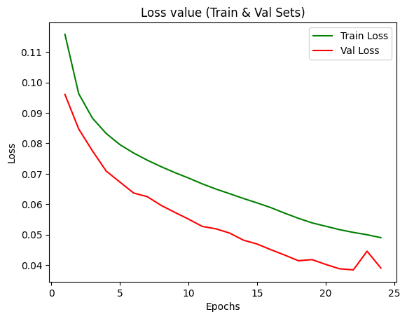

```python
loss_function = grugru_all_model_history.history['loss']
val_loss_function = grugru_all_model_history.history['val_loss']

epochs=range(1,len(loss_function)+1)

plt.title('Loss value (Train & Val Sets)')
plt.plot(epochs,loss_function,color='green',label='Train Loss')
plt.plot(epochs,val_loss_function,color='red',label='Val Loss')
plt.xlabel('Epochs')
plt.ylabel('Loss')
plt.legend()
plt.show()
```

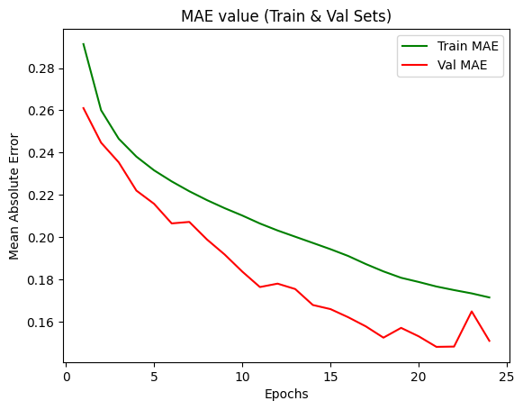

```python
mae_function = grugru_all_model_history.history['mae']
val_mae_function = grugru_all_model_history.history['val_mae']

epochs=range(1,len(loss_function)+1)

plt.title('MAE value (Train & Val Sets)')
plt.plot(epochs,mae_function,color='green',label='Train MAE')
plt.plot(epochs,val_mae_function,color='red',label='Val MAE')
plt.xlabel('Epochs')
plt.ylabel('Mean Absolute Error')
plt.legend()
plt.show()
```

```python
min_max_scaler.fit(y_train_all.reshape(-1, 1))
y_pred = grugru_all_model.predict(X_test_all)
y_pred_inv = min_max_scaler.inverse_transform(y_pred)
y_test_inv = min_max_scaler.inverse_transform(y_test_all.reshape(-1,1))
print('MSE = ',round(mean_squared_error(y_true=y_test_inv,y_pred=y_pred_inv),3),' K degrees')
print('MAE = ',round(mean_absolute_error(y_true=y_test_inv,y_pred=y_pred_inv),3),' K degrees')
print('R2-score = ',round(r2_score(y_test_inv,y_pred_inv),3))
```

```
MSE =  0.037  K degrees
MAE =  0.153  K degrees
R2-score =  0.712
```

```python
x = X_test_all[2]
x = x.reshape((1,) + x.shape)
y_pred = grugru_all_model.predict(x)
y_pred_inv = min_max_scaler.inverse_transform(y_pred)
truth = y_test_all[2]
truth_inv = min_max_scaler.inverse_transform(truth.reshape(-1, 1))
print('Предсказанная температура:', y_pred_inv[0, 0])
print('Реальная температура:', truth_inv[0, 0])
```

```
Предсказанная температура: 0.39586365
Реальная температура: 0.32188841201716656
```

### Вывод

Набор данных Погода в Якутстке содержал пропущенные значения, строки с ними были удалены. Значения в столбце DD были преобразованы с помощью функции get_dummies.Для обучения базовых моделей использовался только признак T, для обучения вторых моделей использовались все признаки, кроме LocalTime. Датасет был разделен на 3 части: тренировочную (70%), тестовую (20%) и валидационную (10%).

Оценка качества регрессоров происходила по следующим метрикам: MSE, MAE и R2.

Среди трёх моделей регрессоров, которые обучались только на признаке T, лучше всего сработали модели с GRU и со стеком двух слоёв с GRU. У них одинаковые значения метрик: MSE = 0.0, MAE = 0.007 и R2 = 0.999.

Среди трёх моделей регрессоров, которые обучались только на всех признаках, лучше всего сработала модель с SimpleRNN. Значения метрик: MSE = 0.006, MAE = 0.031 и R2 = 0.951.